# R Notebook

### The labels on my x-axis are overlapping, and illegible. What should I do?

If this is happening, we can add + coord_flip() to display the x-axis on the y-axis and vice versa. This often fixes the issue. For example, notice how the labels overlap when I plot states below:

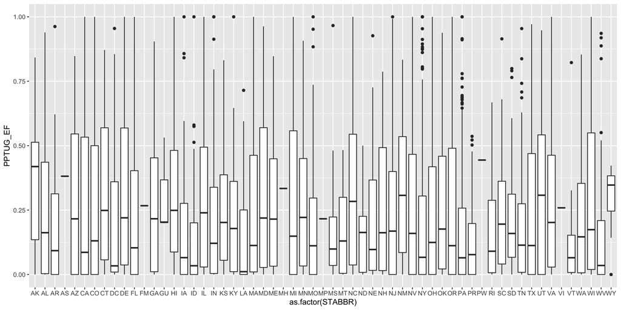

```r
scorecard %>%
  ggplot(aes(x = as.factor(STABBR), y = PPTUG_EF)) + geom_boxplot()
```

I can fix this with + coord_flip(). Note that I might also want to adjust my figure size to account for this.

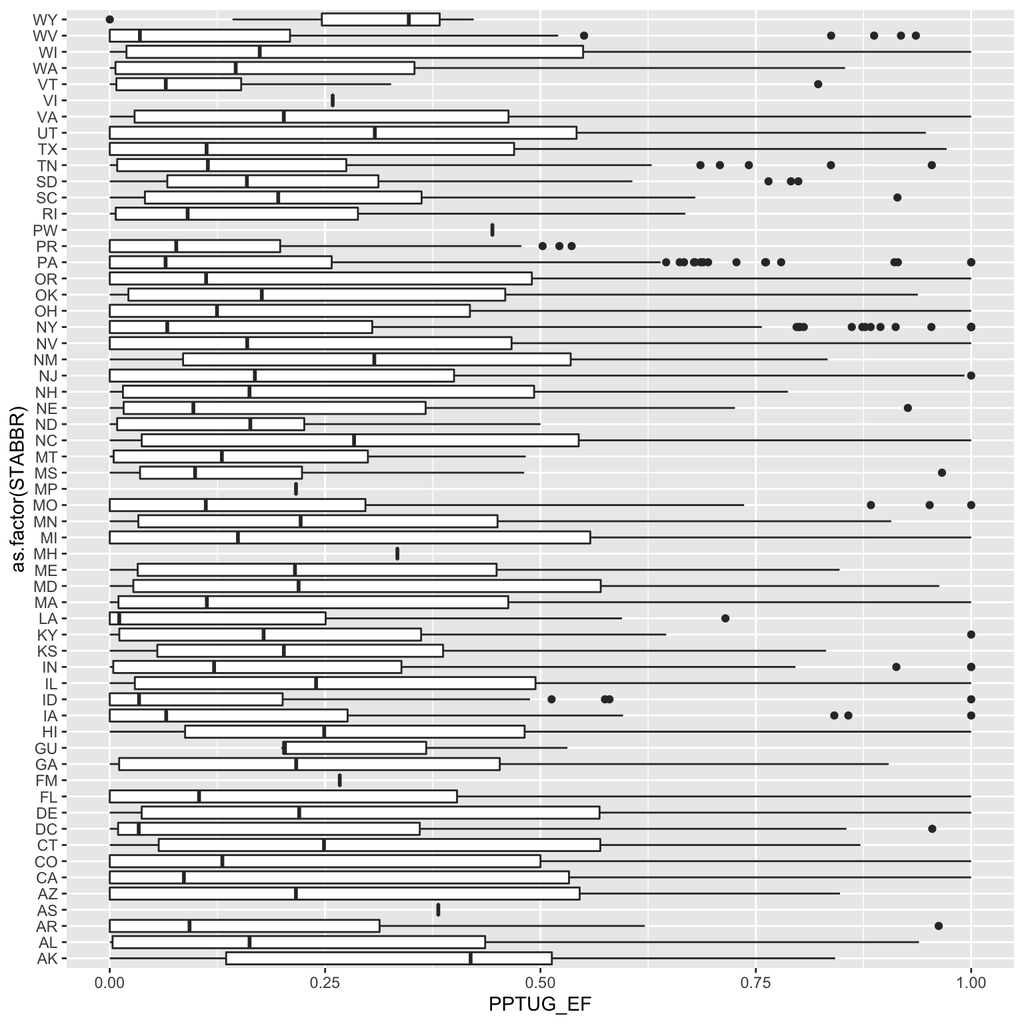

```r
scorecard %>%
  ggplot(aes(x = as.factor(STABBR), y = PPTUG_EF)) + geom_boxplot() + coord_flip()
```